# Wrangle and Analyze Data

- Introduction
- Gathering Data
- Assessing Data
  - Quality
  - Tidiness
- Cleaning Data
- Storing Data
- Analysis and Visuals
- Sources

### Introduction

This project will illustrate the data wrangling process. The dataset that is being wrangled comes from the tweet archive of Twitter user [@dog_rates](https://twitter.com/dog_rates), also known as WeRateDogs. WeRateDogs is a Twitter account that rate's people's dogs with a humorous comment about the dog. These ratings almost always have a denominator of 10 and numerators almost always greater than 10. With this data, I will try to create interesting and trustworthy analyses and visualizations.

### Gathering Data

There are 3 pieces of data required for this project. The first one is the WeRateDogs Twitter archive. This file is given to us and will be treated like an internal file.

```python
# import libraries
import datetime
import json
import matplotlib.pyplot as plt
import matplotlib.dates as mdates
import matplotlib.cbook as cbook
import numpy as np
import pandas as pd
import re
import requests
import seaborn as sns
import time
import tweepy

from functools import reduce

%matplotlib inline
```

```python
# open the csv file
twitter_archive = pd.read_csv('twitter-archive-enhanced-2.csv')
```

```python
# i'm setting the column widths to be bigger so it displays more information
pd.set_option('display.max_colwidth', 200)
```

```python
# look at the data
twitter_archive.head()
```

|  | tweet_id | in_reply_to_status_id | in_reply_to_user_id | timestamp | source | text | retweeted_status_id | retweeted_status_user_id | retweeted_status_timestamp | expanded_urls | rating_numerator | rating_denominator | name | doggo | floofer | pupper | puppo |
| --- | --- | --- | --- | --- | --- | --- | --- | --- | --- | --- | --- | --- | --- | --- | --- | --- | --- |
| 0 | 892420643555336193 | NaN | NaN | 2017-08-01 16:23:56 +0000 | <a href="http://twitter.com/download/iphone" rel="nofollow">Twitter for iPhone</a> | This is Phineas. He's a mystical boy. Only ever appears in the hole of a donut. 13/10 https://t.co/MgUWQ76dJU | NaN | NaN | NaN | https://twitter.com/dog_rates/status/892420643555336193/photo/1 | 13 | 10 | Phineas | None | None | None | None |
| 1 | 892177421306343426 | NaN | NaN | 2017-08-01 00:17:27 +0000 | <a href="http://twitter.com/download/iphone" rel="nofollow">Twitter for iPhone</a> | This is Tilly. She's just checking pup on you. Hopes you're doing ok. If not, she's available for pats, snugs, boops, the whole bit. 13/10 https://t.co/0Xxu71qeIV | NaN | NaN | NaN | https://twitter.com/dog_rates/status/892177421306343426/photo/1 | 13 | 10 | Tilly | None | None | None | None |
| 2 | 891815181378084864 | NaN | NaN | 2017-07-31 00:18:03 +0000 | <a href="http://twitter.com/download/iphone" rel="nofollow">Twitter for iPhone</a> | This is Archie. He is a rare Norwegian Pouncing Corgo. Lives in the tall grass. You never know when one may strike. 12/10 https://t.co/wUnZnhtVJB | NaN | NaN | NaN | https://twitter.com/dog_rates/status/891815181378084864/photo/1 | 12 | 10 | Archie | None | None | None | None |
| 3 | 891689557279858688 | NaN | NaN | 2017-07-30 15:58:51 +0000 | <a href="http://twitter.com/download/iphone" rel="nofollow">Twitter for iPhone</a> | This is Darla. She commenced a snooze mid meal. 13/10 happens to the best of us https://t.co/tD36da7qLQ | NaN | NaN | NaN | https://twitter.com/dog_rates/status/891689557279858688/photo/1 | 13 | 10 | Darla | None | None | None | None |
| 4 | 891327558926688256 | NaN | NaN | 2017-07-29 16:00:24 +0000 | <a href="http://twitter.com/download/iphone" rel="nofollow">Twitter for iPhone</a> | This is Franklin. He would like you to stop calling him "cute." He is a very fierce shark and should be respected as such. 12/10 #BarkWeek https://t.co/AtUZn91f7f | NaN | NaN | NaN | https://twitter.com/dog_rates/status/891327558926688256/photo/1,https://twitter.com/dog_rates/status/891327558926688256/photo/1 | 12 | 10 | Franklin | None | None | None | None |

The second piece of data is tweet image predictions. The file is hosted on Udacity's servers and will be downloaded programmatically using the Requests library and the following URL: [https://d17h27t6h515a5.cloudfront.net/topher/2017/August/599fd2ad_image-predictions/image-predictions.tsv].

```python
# this is the URL given to us to download from
url = 'https://d17h27t6h515a5.cloudfront.net/topher/2017/August/599fd2ad_image-predictions/image-predictions.tsv'

# get the website and store it in response
response = requests.get(url)
response
#response 200 means that our request was successful
```

```
<Response [200]>
```

```python
# we can check the content with this line of code, just uncomment it if you want to check
#response.content
```

```python
# we will open a file called image-predictions.tsv
# we then write the contents of the response variable to it
open('image_predictions.tsv', 'wb').write(response.content)
```

```
335079
```

```python
# we now read the tsv file we just created
image_preds = pd.read_csv('image_predictions.tsv', sep = '\t')
```

```python
# view the data
image_preds.head()
```

|  | tweet_id | jpg_url | img_num | p1 | p1_conf | p1_dog | p2 | p2_conf | p2_dog | p3 | p3_conf | p3_dog |
| --- | --- | --- | --- | --- | --- | --- | --- | --- | --- | --- | --- | --- |
| 0 | 666020888022790149 | https://pbs.twimg.com/media/CT4udn0WwAA0aMy.jpg | 1 | Welsh_springer_spaniel | 0.465074 | True | collie | 0.156665 | True | Shetland_sheepdog | 0.061428 | True |
| 1 | 666029285002620928 | https://pbs.twimg.com/media/CT42GRgUYAA5iDo.jpg | 1 | redbone | 0.506826 | True | miniature_pinscher | 0.074192 | True | Rhodesian_ridgeback | 0.072010 | True |
| 2 | 666033412701032449 | https://pbs.twimg.com/media/CT4521TWwAEvMyu.jpg | 1 | German_shepherd | 0.596461 | True | malinois | 0.138584 | True | bloodhound | 0.116197 | True |
| 3 | 666044226329800704 | https://pbs.twimg.com/media/CT5Dr8HUEAA-lEu.jpg | 1 | Rhodesian_ridgeback | 0.408143 | True | redbone | 0.360687 | True | miniature_pinscher | 0.222752 | True |
| 4 | 666049248165822465 | https://pbs.twimg.com/media/CT5IQmsXIAAKY4A.jpg | 1 | miniature_pinscher | 0.560311 | True | Rottweiler | 0.243682 | True | Doberman | 0.154629 | True |

The third piece of data will be queried from Twitter's API. Using the tweet ID's in the WeRateDogs Twitter archive, query the Twitter API for each tweet's JSON data using Python's Tweepy library and store each tweet's entire set of JSON data in a file called tweet_json.txt. Each tweet's JSON data should be written to its own line. Then read this .txt file line by line into a pandas DataFrame with (at minimum) tweet ID, retweet count, and favorite count.

```python
# set up Twitter api
# the keys are intentionally left blank, you need your own keys to run this code
consumer_key = ''
consumer_secret = ''
access_token = ''
access_secret = ''

# create a OAuth instance and pass in our keys
auth = tweepy.OAuthHandler(consumer_key, consumer_secret)
# set access token
auth.set_access_token(access_token, access_secret)

api = tweepy.API(auth, parser = tweepy.parsers.JSONParser())
```

```python
# query Twitter's API for WeRateDogs JSON data
# match tweet ID from archive to WeRateDogs tweets

# list of tweets that were not retrieved successfully
error_list = []
# list of tweets that were retrieved sucessfully
success_list = []
# start the timer to see how long it will take to retrieve all the tweets
start = time.time()

for tweet_id in twitter_archive['tweet_id']:
    try:
        # get the tweet using ID
        data = api.get_status(tweet_id, tweet_mode = 'extended',
                             wait_on_rate_limit = True,
                             wait_on_rate_limit_notify = True)
        success_list.append(data)
    except:
        error_list.append(tweet_id)
        # I'm printing out the tweet id's that failed
        print('F', tweet_id)

end = time.time()
print('Time it took to retrieve tweets is ', '{:.4f}'.format(end - start), ' in seconds')
```

```
F 888202515573088257
F 873697596434513921
F 872668790621863937
F 872261713294495745
F 869988702071779329
F 866816280283807744
F 861769973181624320
F 856602993587888130
F 851953902622658560
F 845459076796616705
F 844704788403113984
F 842892208864923648
F 837366284874571778
F 837012587749474308
F 829374341691346946
F 827228250799742977
F 812747805718642688
F 802247111496568832
F 779123168116150273
F 775096608509886464
F 771004394259247104
F 770743923962707968
F 759566828574212096
```

```
Rate limit reached. Sleeping for: 638
```

```
F 754011816964026368
F 680055455951884288
```

```
Rate limit reached. Sleeping for: 538
```

```
Time it took to retrieve tweets is  1981.2136  in seconds
```

```python
# format is hours : minutes : seconds : microseconds
str(datetime.timedelta(seconds=(end-start)))
```

```
'0:33:01.213641'
```

```python
# i'm making a second attempt to get the Tweets that failed
retry_list = []
retry_error_list = []
start = time.time()

for tweet_id in error_list:
    try:
        # get the tweet using ID
        data = api.get_status(tweet_id, tweet_mode = 'extended',
                             wait_on_rate_limit = True,
                             wait_on_rate_limit_notify = True)
        retry_list.append(data)
    except:
        retry_error_list.append(tweet_id)
        # I'm printing out the tweet id's that failed
        print('F', tweet_id)

end = time.time()
print('Time it took to retrieve tweets is ', '{:.4f}'.format(end - start), ' in seconds')
```

```
F 888202515573088257
F 873697596434513921
F 872668790621863937
F 872261713294495745
F 869988702071779329
F 866816280283807744
F 861769973181624320
F 856602993587888130
F 851953902622658560
F 845459076796616705
F 844704788403113984
F 842892208864923648
F 837366284874571778
F 837012587749474308
F 829374341691346946
F 827228250799742977
F 812747805718642688
F 802247111496568832
F 779123168116150273
F 775096608509886464
F 771004394259247104
F 770743923962707968
F 759566828574212096
F 754011816964026368
F 680055455951884288
Time it took to retrieve tweets is  6.3039  in seconds
```

```python
# store the data into tweet_json.txt
with open('tweet_json.txt', mode = 'w') as file:
    json.dump(success_list, file)
```

```python
# open the JSON text and put it into a DataFrame
query_data = pd.read_json('tweet_json.txt')
```

```python
query_data.head()
```

|  | created_at | id | id_str | full_text | truncated | display_text_range | entities | extended_entities | source | in_reply_to_status_id | ... | favorited | retweeted | possibly_sensitive | possibly_sensitive_appealable | lang | retweeted_status | quoted_status_id | quoted_status_id_str | quoted_status_permalink | quoted_status |
| --- | --- | --- | --- | --- | --- | --- | --- | --- | --- | --- | --- | --- | --- | --- | --- | --- | --- | --- | --- | --- | --- |
| 0 | 2017-08-01 16:23:56+00:00 | 892420643555336193 | 892420643555336192 | This is Phineas. He's a mystical boy. Only ever appears in the hole of a donut. 13/10 https://t.co/MgUWQ76dJU | False | [0, 85] | {'hashtags': [], 'symbols': [], 'user_mentions': [], 'urls': [], 'media': [{'id': 892420639486877696, 'id_str': '892420639486877696', 'indices': [86, 109], 'media_url': 'http://pbs.twimg.com/media... | {'media': [{'id': 892420639486877696, 'id_str': '892420639486877696', 'indices': [86, 109], 'media_url': 'http://pbs.twimg.com/media/DGKD1-bXoAAIAUK.jpg', 'media_url_https': 'https://pbs.twimg.com... | <a href="http://twitter.com/download/iphone" rel="nofollow">Twitter for iPhone</a> | NaN | ... | False | False | 0.0 | 0.0 | en | NaN | NaN | NaN | NaN | NaN |
| 1 | 2017-08-01 00:17:27+00:00 | 892177421306343426 | 892177421306343424 | This is Tilly. She's just checking pup on you. Hopes you're doing ok. If not, she's available for pats, snugs, boops, the whole bit. 13/10 https://t.co/0Xxu71qeIV | False | [0, 138] | {'hashtags': [], 'symbols': [], 'user_mentions': [], 'urls': [], 'media': [{'id': 892177413194625024, 'id_str': '892177413194625024', 'indices': [139, 162], 'media_url': 'http://pbs.twimg.com/medi... | {'media': [{'id': 892177413194625024, 'id_str': '892177413194625024', 'indices': [139, 162], 'media_url': 'http://pbs.twimg.com/media/DGGmoV4XsAAUL6n.jpg', 'media_url_https': 'https://pbs.twimg.co... | <a href="http://twitter.com/download/iphone" rel="nofollow">Twitter for iPhone</a> | NaN | ... | False | False | 0.0 | 0.0 | en | NaN | NaN | NaN | NaN | NaN |
| 2 | 2017-07-31 00:18:03+00:00 | 891815181378084864 | 891815181378084864 | This is Archie. He is a rare Norwegian Pouncing Corgo. Lives in the tall grass. You never know when one may strike. 12/10 https://t.co/wUnZnhtVJB | False | [0, 121] | {'hashtags': [], 'symbols': [], 'user_mentions': [], 'urls': [], 'media': [{'id': 891815175371796480, 'id_str': '891815175371796480', 'indices': [122, 145], 'media_url': 'http://pbs.twimg.com/medi... | {'media': [{'id': 891815175371796480, 'id_str': '891815175371796480', 'indices': [122, 145], 'media_url': 'http://pbs.twimg.com/media/DGBdLU1WsAANxJ9.jpg', 'media_url_https': 'https://pbs.twimg.co... | <a href="http://twitter.com/download/iphone" rel="nofollow">Twitter for iPhone</a> | NaN | ... | False | False | 0.0 | 0.0 | en | NaN | NaN | NaN | NaN | NaN |
| 3 | 2017-07-30 15:58:51+00:00 | 891689557279858688 | 891689557279858688 | This is Darla. She commenced a snooze mid meal. 13/10 happens to the best of us https://t.co/tD36da7qLQ | False | [0, 79] | {'hashtags': [], 'symbols': [], 'user_mentions': [], 'urls': [], 'media': [{'id': 891689552724799489, 'id_str': '891689552724799489', 'indices': [80, 103], 'media_url': 'http://pbs.twimg.com/media... | {'media': [{'id': 891689552724799489, 'id_str': '891689552724799489', 'indices': [80, 103], 'media_url': 'http://pbs.twimg.com/media/DF_q7IAWsAEuuN8.jpg', 'media_url_https': 'https://pbs.twimg.com... | <a href="http://twitter.com/download/iphone" rel="nofollow">Twitter for iPhone</a> | NaN | ... | False | False | 0.0 | 0.0 | en | NaN | NaN | NaN | NaN | NaN |
| 4 | 2017-07-29 16:00:24+00:00 | 891327558926688256 | 891327558926688256 | This is Franklin. He would like you to stop calling him "cute." He is a very fierce shark and should be respected as such. 12/10 #BarkWeek https://t.co/AtUZn91f7f | False | [0, 138] | {'hashtags': [{'text': 'BarkWeek', 'indices': [129, 138]}], 'symbols': [], 'user_mentions': [], 'urls': [], 'media': [{'id': 891327551943041024, 'id_str': '891327551943041024', 'indices': [139, 16... | {'media': [{'id': 891327551943041024, 'id_str': '891327551943041024', 'indices': [139, 162], 'media_url': 'http://pbs.twimg.com/media/DF6hr6AVYAAZ8G8.jpg', 'media_url_https': 'https://pbs.twimg.co... | <a href="http://twitter.com/download/iphone" rel="nofollow">Twitter for iPhone</a> | NaN | ... | False | False | 0.0 | 0.0 | en | NaN | NaN | NaN | NaN | NaN |

5 rows × 32 columns

```python
query_data.info()
```

```
<class 'pandas.core.frame.DataFrame'>
RangeIndex: 2331 entries, 0 to 2330
Data columns (total 32 columns):
created_at                       2331 non-null datetime64[ns, UTC]
id                               2331 non-null int64
id_str                           2331 non-null int64
full_text                        2331 non-null object
truncated                        2331 non-null bool
display_text_range               2331 non-null object
entities                         2331 non-null object
extended_entities                2059 non-null object
source                           2331 non-null object
in_reply_to_status_id            77 non-null float64
in_reply_to_status_id_str        77 non-null float64
in_reply_to_user_id              77 non-null float64
in_reply_to_user_id_str          77 non-null float64
in_reply_to_screen_name          77 non-null object
user                             2331 non-null object
geo                              0 non-null float64
coordinates                      0 non-null float64
place                            1 non-null object
contributors                     0 non-null float64
is_quote_status                  2331 non-null bool
retweet_count                    2331 non-null int64
favorite_count                   2331 non-null int64
favorited                        2331 non-null bool
retweeted                        2331 non-null bool
possibly_sensitive               2196 non-null float64
possibly_sensitive_appealable    2196 non-null float64
lang                             2331 non-null object
retweeted_status                 163 non-null object
quoted_status_id                 26 non-null float64
quoted_status_id_str             26 non-null float64
quoted_status_permalink          26 non-null object
quoted_status                    24 non-null object
dtypes: bool(4), datetime64[ns, UTC](1), float64(11), int64(4), object(12)
memory usage: 519.1+ KB
```

```python
query_data['tweet_id'] = query_data['id']
query_data = query_data[['tweet_id', 'retweet_count', 'favorite_count']]
query_data.head()
```

|  | tweet_id | retweet_count | favorite_count |
| --- | --- | --- | --- |
| 0 | 892420643555336193 | 7699 | 36161 |
| 1 | 892177421306343426 | 5694 | 31183 |
| 2 | 891815181378084864 | 3777 | 23486 |
| 3 | 891689557279858688 | 7859 | 39432 |
| 4 | 891327558926688256 | 8475 | 37640 |

### Assessing Data

Detect and document at least eight quality issues and two tidiness issues.

I'll use pandas to visually assess the three dataframes. The better option would be to look at them in a spreadsheet program since pandas collapses rows and columns. It is also less convenient to scroll around in pandas.

```python
# to view the entire dataset, a csv viewer would be a better option
twitter_archive
```

|  | tweet_id | in_reply_to_status_id | in_reply_to_user_id | timestamp | source | text | retweeted_status_id | retweeted_status_user_id | retweeted_status_timestamp | expanded_urls | rating_numerator | rating_denominator | name | doggo | floofer | pupper | puppo |
| --- | --- | --- | --- | --- | --- | --- | --- | --- | --- | --- | --- | --- | --- | --- | --- | --- | --- |
| 0 | 892420643555336193 | NaN | NaN | 2017-08-01 16:23:56 +0000 | <a href="http://twitter.com/download/iphone" rel="nofollow">Twitter for iPhone</a> | This is Phineas. He's a mystical boy. Only ever appears in the hole of a donut. 13/10 https://t.co/MgUWQ76dJU | NaN | NaN | NaN | https://twitter.com/dog_rates/status/892420643555336193/photo/1 | 13 | 10 | Phineas | None | None | None | None |
| 1 | 892177421306343426 | NaN | NaN | 2017-08-01 00:17:27 +0000 | <a href="http://twitter.com/download/iphone" rel="nofollow">Twitter for iPhone</a> | This is Tilly. She's just checking pup on you. Hopes you're doing ok. If not, she's available for pats, snugs, boops, the whole bit. 13/10 https://t.co/0Xxu71qeIV | NaN | NaN | NaN | https://twitter.com/dog_rates/status/892177421306343426/photo/1 | 13 | 10 | Tilly | None | None | None | None |
| 2 | 891815181378084864 | NaN | NaN | 2017-07-31 00:18:03 +0000 | <a href="http://twitter.com/download/iphone" rel="nofollow">Twitter for iPhone</a> | This is Archie. He is a rare Norwegian Pouncing Corgo. Lives in the tall grass. You never know when one may strike. 12/10 https://t.co/wUnZnhtVJB | NaN | NaN | NaN | https://twitter.com/dog_rates/status/891815181378084864/photo/1 | 12 | 10 | Archie | None | None | None | None |
| 3 | 891689557279858688 | NaN | NaN | 2017-07-30 15:58:51 +0000 | <a href="http://twitter.com/download/iphone" rel="nofollow">Twitter for iPhone</a> | This is Darla. She commenced a snooze mid meal. 13/10 happens to the best of us https://t.co/tD36da7qLQ | NaN | NaN | NaN | https://twitter.com/dog_rates/status/891689557279858688/photo/1 | 13 | 10 | Darla | None | None | None | None |
| 4 | 891327558926688256 | NaN | NaN | 2017-07-29 16:00:24 +0000 | <a href="http://twitter.com/download/iphone" rel="nofollow">Twitter for iPhone</a> | This is Franklin. He would like you to stop calling him "cute." He is a very fierce shark and should be respected as such. 12/10 #BarkWeek https://t.co/AtUZn91f7f | NaN | NaN | NaN | https://twitter.com/dog_rates/status/891327558926688256/photo/1,https://twitter.com/dog_rates/status/891327558926688256/photo/1 | 12 | 10 | Franklin | None | None | None | None |
| ... | ... | ... | ... | ... | ... | ... | ... | ... | ... | ... | ... | ... | ... | ... | ... | ... | ... |
| 2351 | 666049248165822465 | NaN | NaN | 2015-11-16 00:24:50 +0000 | <a href="http://twitter.com/download/iphone" rel="nofollow">Twitter for iPhone</a> | Here we have a 1949 1st generation vulpix. Enjoys sweat tea and Fox News. Cannot be phased. 5/10 https://t.co/4B7cOc1EDq | NaN | NaN | NaN | https://twitter.com/dog_rates/status/666049248165822465/photo/1 | 5 | 10 | None | None | None | None | None |
| 2352 | 666044226329800704 | NaN | NaN | 2015-11-16 00:04:52 +0000 | <a href="http://twitter.com/download/iphone" rel="nofollow">Twitter for iPhone</a> | This is a purebred Piers Morgan. Loves to Netflix and chill. Always looks like he forgot to unplug the iron. 6/10 https://t.co/DWnyCjf2mx | NaN | NaN | NaN | https://twitter.com/dog_rates/status/666044226329800704/photo/1 | 6 | 10 | a | None | None | None | None |
| 2353 | 666033412701032449 | NaN | NaN | 2015-11-15 23:21:54 +0000 | <a href="http://twitter.com/download/iphone" rel="nofollow">Twitter for iPhone</a> | Here is a very happy pup. Big fan of well-maintained decks. Just look at that tongue. 9/10 would cuddle af https://t.co/y671yMhoiR | NaN | NaN | NaN | https://twitter.com/dog_rates/status/666033412701032449/photo/1 | 9 | 10 | a | None | None | None | None |
| 2354 | 666029285002620928 | NaN | NaN | 2015-11-15 23:05:30 +0000 | <a href="http://twitter.com/download/iphone" rel="nofollow">Twitter for iPhone</a> | This is a western brown Mitsubishi terrier. Upset about leaf. Actually 2 dogs here. 7/10 would walk the shit out of https://t.co/r7mOb2m0UI | NaN | NaN | NaN | https://twitter.com/dog_rates/status/666029285002620928/photo/1 | 7 | 10 | a | None | None | None | None |
| 2355 | 666020888022790149 | NaN | NaN | 2015-11-15 22:32:08 +0000 | <a href="http://twitter.com/download/iphone" rel="nofollow">Twitter for iPhone</a> | Here we have a Japanese Irish Setter. Lost eye in Vietnam (?). Big fan of relaxing on stair. 8/10 would pet https://t.co/BLDqew2Ijj | NaN | NaN | NaN | https://twitter.com/dog_rates/status/666020888022790149/photo/1 | 8 | 10 | None | None | None | None | None |

2356 rows × 17 columns

```python
twitter_archive.info()
```

```
<class 'pandas.core.frame.DataFrame'>
RangeIndex: 2356 entries, 0 to 2355
Data columns (total 17 columns):
tweet_id                      2356 non-null int64
in_reply_to_status_id         78 non-null float64
in_reply_to_user_id           78 non-null float64
timestamp                     2356 non-null object
source                        2356 non-null object
text                          2356 non-null object
retweeted_status_id           181 non-null float64
retweeted_status_user_id      181 non-null float64
retweeted_status_timestamp    181 non-null object
expanded_urls                 2297 non-null object
rating_numerator              2356 non-null int64
rating_denominator            2356 non-null int64
name                          2356 non-null object
doggo                         2356 non-null object
floofer                       2356 non-null object
pupper                        2356 non-null object
puppo                         2356 non-null object
dtypes: float64(4), int64(3), object(10)
memory usage: 313.0+ KB
```

```python
# investigate what the object data types actually are
type(twitter_archive.timestamp[0]), type(twitter_archive.source[0]), type(twitter_archive.text[0])
```

```
(str, str, str)
```

```python
type(twitter_archive.retweeted_status_timestamp[0]), type(twitter_archive.expanded_urls[0])
```

```
(float, str)
```

```python
type(twitter_archive.name[0]), type(twitter_archive.doggo[0])
```

```
(str, str)
```

```python
type(twitter_archive.floofer[0]), type(twitter_archive.pupper[0]), type(twitter_archive.puppo[0])
```

```
(str, str, str)
```

```python
# checking what values are in numerator and denominator
twitter_archive.rating_numerator.value_counts()
```

```
12      558
11      464
10      461
13      351
9       158
8       102
7        55
14       54
5        37
6        32
3        19
4        17
1         9
2         9
420       2
```

[output cut: 26 more lines]

```python
twitter_archive.query('rating_numerator < 10').head()
```

|  | tweet_id | in_reply_to_status_id | in_reply_to_user_id | timestamp | source | text | retweeted_status_id | retweeted_status_user_id | retweeted_status_timestamp | expanded_urls | rating_numerator | rating_denominator | name | doggo | floofer | pupper | puppo |
| --- | --- | --- | --- | --- | --- | --- | --- | --- | --- | --- | --- | --- | --- | --- | --- | --- | --- |
| 45 | 883482846933004288 | NaN | NaN | 2017-07-08 00:28:19 +0000 | <a href="http://twitter.com/download/iphone" rel="nofollow">Twitter for iPhone</a> | This is Bella. She hopes her smile made you smile. If not, she is also offering you her favorite monkey. 13.5/10 https://t.co/qjrljjt948 | NaN | NaN | NaN | https://twitter.com/dog_rates/status/883482846933004288/photo/1,https://twitter.com/dog_rates/status/883482846933004288/photo/1 | 5 | 10 | Bella | None | None | None | None |
| 229 | 848212111729840128 | NaN | NaN | 2017-04-01 16:35:01 +0000 | <a href="http://twitter.com/download/iphone" rel="nofollow">Twitter for iPhone</a> | This is Jerry. He's doing a distinguished tongue slip. Slightly patronizing tbh. You think you're better than us, Jerry? 6/10 hold me back https://t.co/DkOBbwulw1 | NaN | NaN | NaN | https://twitter.com/dog_rates/status/848212111729840128/photo/1 | 6 | 10 | Jerry | None | None | None | None |
| 315 | 835152434251116546 | NaN | NaN | 2017-02-24 15:40:31 +0000 | <a href="http://twitter.com/download/iphone" rel="nofollow">Twitter for iPhone</a> | When you're so blinded by your systematic plagiarism that you forget what day it is. 0/10 https://t.co/YbEJPkg4Ag | NaN | NaN | NaN | https://twitter.com/dog_rates/status/835152434251116546/photo/1,https://twitter.com/dog_rates/status/835152434251116546/photo/1,https://twitter.com/dog_rates/status/835152434251116546/photo/1 | 0 | 10 | None | None | None | None | None |
| 387 | 826598799820865537 | 8.265984e+17 | 4.196984e+09 | 2017-02-01 01:11:25 +0000 | <a href="http://twitter.com/download/iphone" rel="nofollow">Twitter for iPhone</a> | I was going to do 007/10, but the joke wasn't worth the &lt;10 rating | NaN | NaN | NaN | NaN | 7 | 10 | None | None | None | None | None |
| 462 | 817502432452313088 | NaN | NaN | 2017-01-06 22:45:43 +0000 | <a href="http://twitter.com/download/iphone" rel="nofollow">Twitter for iPhone</a> | RT @dog_rates: Meet Herschel. He's slightly bigger than ur average pupper. Looks lonely. Could probably ride 7/10 would totally pet https:/… | 6.924173e+17 | 4.196984e+09 | 2016-01-27 18:42:06 +0000 | https://twitter.com/dog_rates/status/692417313023332352/photo/1 | 7 | 10 | Herschel | None | None | pupper | None |

```python
twitter_archive.rating_denominator.value_counts()
```

```
10     2333
11        3
50        3
80        2
20        2
2         1
16        1
40        1
70        1
15        1
90        1
110       1
120       1
130       1
150       1
170       1
7         1
0         1
Name: rating_denominator, dtype: int64
```

```python
# checking if there are duplicate tweet_ids present in dataset
sum(twitter_archive.tweet_id.duplicated())
```

```
0
```

```python
# checking validity of dog names, scrolling through the data i found some names such as: a, an, None
twitter_archive.name.unique()
```

```
array(['Phineas', 'Tilly', 'Archie', 'Darla', 'Franklin', 'None', 'Jax',
       'Zoey', 'Cassie', 'Koda', 'Bruno', 'Ted', 'Stuart', 'Oliver',
       'Jim', 'Zeke', 'Ralphus', 'Canela', 'Gerald', 'Jeffrey', 'such',
       'Maya', 'Mingus', 'Derek', 'Roscoe', 'Waffles', 'Jimbo', 'Maisey',
       'Lilly', 'Earl', 'Lola', 'Kevin', 'Yogi', 'Noah', 'Bella',
       'Grizzwald', 'Rusty', 'Gus', 'Stanley', 'Alfy', 'Koko', 'Rey',
       'Gary', 'a', 'Elliot', 'Louis', 'Jesse', 'Romeo', 'Bailey',
       'Duddles', 'Jack', 'Emmy', 'Steven', 'Beau', 'Snoopy', 'Shadow',
       'Terrance', 'Aja', 'Penny', 'Dante', 'Nelly', 'Ginger', 'Benedict',
       'Venti', 'Goose', 'Nugget', 'Cash', 'Coco', 'Jed', 'Sebastian',
       'Walter', 'Sierra', 'Monkey', 'Harry', 'Kody', 'Lassie', 'Rover',
       'Napolean', 'Dawn', 'Boomer', 'Cody', 'Rumble', 'Clifford',
       'quite', 'Dewey', 'Scout', 'Gizmo', 'Cooper', 'Harold', 'Shikha',
       'Jamesy', 'Lili', 'Sammy', 'Meatball', 'Paisley', 'Albus',
       'Neptune', 'Quinn', 'Belle', 'Zooey', 'Dave', 'Jersey', 'Hobbes',
       'Burt', 'Lorenzo', 'Carl', 'Jordy', 'Milky', 'Trooper', 'Winston',
       'Sophie', 'Wyatt', 'Rosie', 'Thor', 'Oscar', 'Luna', 'Callie',
       'Cermet', 'George', 'Marlee', 'Arya', 'Einstein', 'Alice',
       'Rumpole', 'Benny', 'Aspen', 'Jarod', 'Wiggles', 'General',
       'Sailor', 'Astrid', 'Iggy', 'Snoop', 'Kyle', 'Leo', 'Riley',
       'Gidget', 'Noosh', 'Odin', 'Jerry', 'Charlie', 'Georgie', 'Rontu',
       'Cannon', 'Furzey', 'Daisy', 'Tuck', 'Barney', 'Vixen', 'Jarvis',
       'Mimosa', 'Pickles', 'Bungalo', 'Brady', 'Margo', 'Sadie', 'Hank',
       'Tycho', 'Stephan', 'Indie', 'Winnie', 'Bentley', 'Ken', 'Max',
       'Maddie', 'Pipsy', 'Monty', 'Sojourner', 'Odie', 'Arlo', 'Sunny',
       'Vincent', 'Lucy', 'Clark', 'Mookie', 'Meera', 'Buddy', 'Ava',
       'Rory', 'Eli', 'Ash', 'Tucker', 'Tobi', 'Chester', 'Wilson',
       'Sunshine', 'Lipton', 'Gabby', 'Bronte', 'Poppy', 'Rhino',
       'Willow', 'not', 'Orion', 'Eevee', 'Smiley', 'Logan', 'Moreton',
       'Klein', 'Miguel', 'Emanuel', 'Kuyu', 'Dutch', 'Pete', 'Scooter',
       'Reggie', 'Kyro', 'Samson', 'Loki', 'Mia', 'Malcolm', 'Dexter',
       'Alfie', 'Fiona', 'one', 'Mutt', 'Bear', 'Doobert', 'Beebop',
       'Alexander', 'Sailer', 'Brutus', 'Kona', 'Boots', 'Ralphie',
       'Phil', 'Cupid', 'Pawnd', 'Pilot', 'Ike', 'Mo', 'Toby', 'Sweet',
       'Pablo', 'Nala', 'Balto', 'Crawford', 'Gabe', 'Mattie', 'Jimison',
       'Hercules', 'Duchess', 'Harlso', 'Sampson', 'Sundance', 'Luca',
       'Flash', 'Finn', 'Peaches', 'Howie', 'Jazzy', 'Anna', 'Bo',
       'Seamus', 'Wafer', 'Chelsea', 'Tom', 'Moose', 'Florence', 'Autumn',
       'Dido', 'Eugene', 'Herschel', 'Strudel', 'Tebow', 'Chloe', 'Betty',
       'Timber', 'Binky', 'Dudley', 'Comet', 'Larry', 'Levi', 'Akumi',
```

[output cut: 88 more lines]

```
       'Anthony', 'Holly', 'Jett', 'Amy', 'Sage', 'Andy', 'Mason',
       'Trigger', 'Antony', 'Creg', 'Traviss', 'Gin', 'Jeffrie', 'Danny',
       'Ester', 'Pluto', 'Bloo', 'Edd', 'Willy', 'Herb', 'Damon',
       'Peanut', 'Nigel', 'Butters', 'Sandra', 'Fabio', 'Randall', 'Liam',
       'Tommy', 'Ben', 'Raphael', 'Julio', 'Andru', 'Kloey', 'Shawwn',
       'Skye', 'Kollin', 'Ronduh', 'Billl', 'Saydee', 'Dug', 'Tessa',
       'Sully', 'Kirk', 'Ralf', 'Clarq', 'Jaspers', 'Samsom', 'Harrison',
       'Chaz', 'Jeremy', 'Jaycob', 'Lambeau', 'Ruffles', 'Amélie', 'Bobb',
       'Banditt', 'Kevon', 'Winifred', 'Hanz', 'Churlie', 'Zeek',
       'Timofy', 'Maks', 'Jomathan', 'Kallie', 'Marvin', 'Spark',
       'Gòrdón', 'Jo', 'DayZ', 'Jareld', 'Torque', 'Ron', 'Skittles',
       'Cleopatricia', 'Erik', 'Stu', 'Tedrick', 'Filup', 'Kial',
       'Naphaniel', 'Dook', 'Hall', 'Philippe', 'Biden', 'Fwed',
       'Genevieve', 'Joshwa', 'Bradlay', 'Clybe', 'Keet', 'Carll',
       'Jockson', 'Josep', 'Lugan', 'Christoper'], dtype=object)
```

```python
# these wouldn't be real names, so i'm checking names less than length 3
twitter_archive.name = twitter_archive.name.astype('str')
print(type(twitter_archive.name))
test = twitter_archive[twitter_archive.name.str.len() < 3]
test.name.value_counts()
```

```
<class 'pandas.core.series.Series'>
```

```
a     55
Bo     9
an     7
by     1
Ed     1
my     1
Al     1
O      1
Jo     1
JD     1
Mo     1
Name: name, dtype: int64
```

```python
# checks names with length = 3
test2 = twitter_archive[twitter_archive.name.str.len() == 3]
test2.name.value_counts()
```

```
the    8
Jax    6
Leo    6
Gus    5
one    4
Max    3
Mia    3
Ted    3
Tyr    2
Eve    2
Doc    2
Ken    2
Ava    2
Moe    2
Lou    2
mad    2
Sam    2
not    2
Eli    2
Bob    2
Ash    2
old    1
Jim    1
Edd    1
Dug    1
Stu    1
Pip    1
Ole    1
Obi    1
Rey    1
Tug    1
Mac    1
Evy    1
Mya    1
Jay    1
Jed    1
Gin    1
Jeb    1
Taz    1
Aja    1
all    1
Cal    1
Dot    1
Ben    1
his    1
Zoe    1
Blu    1
Ace    1
Tom    1
Ito    1
Ron    1
Amy    1
Dex    1
Ike    1
Sky    1
Sid    1
Alf    1
Name: name, dtype: int64
```

```python
# this one is filtering by the first character of name being lowercase
test3 = twitter_archive[twitter_archive.name.str[0].str.islower() == True]
test3.name.value_counts()
```

```
a               55
the              8
an               7
very             5
just             4
quite            4
one              4
actually         2
mad              2
getting          2
not              2
his              1
infuriating      1
space            1
such             1
my               1
all              1
by               1
this             1
incredibly       1
unacceptable     1
old              1
life             1
light            1
officially       1
Name: name, dtype: int64
```

```python
# i'm just checking the total of names
test3.name.count()
```

```
109
```

```python
# a csv viewer would be better to look at image_preds
image_preds
```

|  | tweet_id | jpg_url | img_num | p1 | p1_conf | p1_dog | p2 | p2_conf | p2_dog | p3 | p3_conf | p3_dog |
| --- | --- | --- | --- | --- | --- | --- | --- | --- | --- | --- | --- | --- |
| 0 | 666020888022790149 | https://pbs.twimg.com/media/CT4udn0WwAA0aMy.jpg | 1 | Welsh_springer_spaniel | 0.465074 | True | collie | 0.156665 | True | Shetland_sheepdog | 0.061428 | True |
| 1 | 666029285002620928 | https://pbs.twimg.com/media/CT42GRgUYAA5iDo.jpg | 1 | redbone | 0.506826 | True | miniature_pinscher | 0.074192 | True | Rhodesian_ridgeback | 0.072010 | True |
| 2 | 666033412701032449 | https://pbs.twimg.com/media/CT4521TWwAEvMyu.jpg | 1 | German_shepherd | 0.596461 | True | malinois | 0.138584 | True | bloodhound | 0.116197 | True |
| 3 | 666044226329800704 | https://pbs.twimg.com/media/CT5Dr8HUEAA-lEu.jpg | 1 | Rhodesian_ridgeback | 0.408143 | True | redbone | 0.360687 | True | miniature_pinscher | 0.222752 | True |
| 4 | 666049248165822465 | https://pbs.twimg.com/media/CT5IQmsXIAAKY4A.jpg | 1 | miniature_pinscher | 0.560311 | True | Rottweiler | 0.243682 | True | Doberman | 0.154629 | True |
| ... | ... | ... | ... | ... | ... | ... | ... | ... | ... | ... | ... | ... |
| 2070 | 891327558926688256 | https://pbs.twimg.com/media/DF6hr6BUMAAzZgT.jpg | 2 | basset | 0.555712 | True | English_springer | 0.225770 | True | German_short-haired_pointer | 0.175219 | True |
| 2071 | 891689557279858688 | https://pbs.twimg.com/media/DF_q7IAWsAEuuN8.jpg | 1 | paper_towel | 0.170278 | False | Labrador_retriever | 0.168086 | True | spatula | 0.040836 | False |
| 2072 | 891815181378084864 | https://pbs.twimg.com/media/DGBdLU1WsAANxJ9.jpg | 1 | Chihuahua | 0.716012 | True | malamute | 0.078253 | True | kelpie | 0.031379 | True |
| 2073 | 892177421306343426 | https://pbs.twimg.com/media/DGGmoV4XsAAUL6n.jpg | 1 | Chihuahua | 0.323581 | True | Pekinese | 0.090647 | True | papillon | 0.068957 | True |
| 2074 | 892420643555336193 | https://pbs.twimg.com/media/DGKD1-bXoAAIAUK.jpg | 1 | orange | 0.097049 | False | bagel | 0.085851 | False | banana | 0.076110 | False |

2075 rows × 12 columns

```python
image_preds.info()
```

```
<class 'pandas.core.frame.DataFrame'>
RangeIndex: 2075 entries, 0 to 2074
Data columns (total 12 columns):
tweet_id    2075 non-null int64
jpg_url     2075 non-null object
img_num     2075 non-null int64
p1          2075 non-null object
p1_conf     2075 non-null float64
p1_dog      2075 non-null bool
p2          2075 non-null object
p2_conf     2075 non-null float64
p2_dog      2075 non-null bool
p3          2075 non-null object
p3_conf     2075 non-null float64
p3_dog      2075 non-null bool
dtypes: bool(3), float64(3), int64(2), object(4)
memory usage: 152.1+ KB
```

```python
# investigate what those objects really are
type(image_preds.jpg_url[0]), type(image_preds.p1[0]), type(image_preds.p2[0]), type(image_preds.p3[0])
```

```
(str, str, str, str)
```

```python
# check if there are any duplicate ids or duplicate jpg_url
sum(image_preds.tweet_id.duplicated()) , sum(image_preds.jpg_url.duplicated())
```

```
(0, 66)
```

```python
# look at query_data
query_data
```

|  | tweet_id | retweet_count | favorite_count |
| --- | --- | --- | --- |
| 0 | 892420643555336193 | 7699 | 36161 |
| 1 | 892177421306343426 | 5694 | 31183 |
| 2 | 891815181378084864 | 3777 | 23486 |
| 3 | 891689557279858688 | 7859 | 39432 |
| 4 | 891327558926688256 | 8475 | 37640 |
| ... | ... | ... | ... |
| 2326 | 666049248165822465 | 40 | 96 |
| 2327 | 666044226329800704 | 131 | 272 |
| 2328 | 666033412701032449 | 41 | 112 |
| 2329 | 666029285002620928 | 42 | 121 |
| 2330 | 666020888022790149 | 461 | 2411 |

2331 rows × 3 columns

```python
query_data.info()
```

```
<class 'pandas.core.frame.DataFrame'>
RangeIndex: 2331 entries, 0 to 2330
Data columns (total 3 columns):
tweet_id          2331 non-null int64
retweet_count     2331 non-null int64
favorite_count    2331 non-null int64
dtypes: int64(3)
memory usage: 54.8 KB
```

```python
sum(query_data.tweet_id.duplicated())
```

```
0
```

```python
# i'm making a csv file for query_data so it can be viewed in Google sheets
query_data.to_csv('query_data.csv', index = False)
```

**Quality**

Completeness: Are we missing data?  
Validity: Does the data conform to realistic values? (ex. A person can't have negative height.)  
Accuracy: Is the data right? (It can be valid and still wrong.)  
Consistency: Is the data in a standard format?

twitter_archive:

- missing data in columns:  
  in_reply_to_status_id,  
  in_reply_to_user_id,  
  retweeted_status_id,  
  retweeted_status_user_id,  
  retweeted_status_timestamp,  
  expanded_urls
- wrong data types:  
  in_reply_to_status_id should be type int  
  in_reply_to_user_id should be type int  
  timestamp should be type datetime  
  retweeted_status_id should be type int  
  retweeted_status_user_id should be type int  
  retweeted_status_timestamp should be type datetime
- there are values in rating_numerator below 10 or has decimal points
- there are values in rating_denominator that aren't 10
- there are invalid names such as: a, an, by, my, O, the, one, mad, not, old, all, his, etc.
- there are retweets (rows where retweeted_status has a value instead of NaN)

image_preds

- missing data, image_preds is a dataset that has image predictions for the twitter_archive dataset  
  twitter_archive has 2356 entries, while image_preds has 2075 entries
- inconsistent capitalization in p1, p2, and p3 columns
- there are duplicate values in jpg_url

query_data

- missing data, twitter_archive has 2356 entries, while query_data has 2331 entries
- there are also retweets in this dataset

**Tidiness**

Each variable forms a column.  
Each observation forms a row.  
Each type of observational unit forms a table.

twitter_archive

- doggo, floofer, pupper, puppo belong to one variable, they are all a 'stage' of dog

image_preds

- the data is a part of twitter_archive observations

query_data

- the data is a part of twitter_archive observations

### Cleaning Data

```python
# make copies of the dataframe before doing any cleaning
twitter_archive_clean = twitter_archive.copy()
image_preds_clean = image_preds.copy()
query_data_clean = query_data.copy()
```

**Define**  
<sup>T1,2</sup> Merge all 3 datasets together.

**Code and Test**

```python
# the list of dataframes I want to merge
dfs = [twitter_archive_clean, image_preds_clean, query_data_clean]
```

```python
# merge them all together, default is inner merge
master_df = reduce(lambda left, right: pd.merge(left,right, on = 'tweet_id'), dfs)
```

```python
# check if merged successfully
master_df.info()
```

```
<class 'pandas.core.frame.DataFrame'>
Int64Index: 2059 entries, 0 to 2058
Data columns (total 30 columns):
tweet_id                      2059 non-null int64
in_reply_to_status_id         23 non-null float64
in_reply_to_user_id           23 non-null float64
timestamp                     2059 non-null object
source                        2059 non-null object
text                          2059 non-null object
retweeted_status_id           72 non-null float64
retweeted_status_user_id      72 non-null float64
retweeted_status_timestamp    72 non-null object
expanded_urls                 2059 non-null object
rating_numerator              2059 non-null int64
rating_denominator            2059 non-null int64
name                          2059 non-null object
doggo                         2059 non-null object
floofer                       2059 non-null object
pupper                        2059 non-null object
puppo                         2059 non-null object
jpg_url                       2059 non-null object
img_num                       2059 non-null int64
p1                            2059 non-null object
p1_conf                       2059 non-null float64
p1_dog                        2059 non-null bool
p2                            2059 non-null object
p2_conf                       2059 non-null float64
p2_dog                        2059 non-null bool
p3                            2059 non-null object
p3_conf                       2059 non-null float64
p3_dog                        2059 non-null bool
retweet_count                 2059 non-null int64
favorite_count                2059 non-null int64
dtypes: bool(3), float64(7), int64(6), object(14)
memory usage: 456.4+ KB
```

**Define**  
<sup>Q1</sup> Delete retweets in the master_df dataframe.

**Code and Test**

```python
# retweets are rows where retweeted_status_id has a value that is not null
# i'm getting the indices of these rows
retweet_indices = master_df.query('retweeted_status_id != "NaN"').index
```

```python
# i'm dropping the rows by their indices
master_df.drop(master_df.index[retweet_indices], inplace = True)
```

```python
# making sure the rows are gone
master_df.query('retweeted_status_id != "NaN"')
```

|  | tweet_id | in_reply_to_status_id | in_reply_to_user_id | timestamp | source | text | retweeted_status_id | retweeted_status_user_id | retweeted_status_timestamp | expanded_urls | ... | p1_conf | p1_dog | p2 | p2_conf | p2_dog | p3 | p3_conf | p3_dog | retweet_count | favorite_count |
| --- | --- | --- | --- | --- | --- | --- | --- | --- | --- | --- | --- | --- | --- | --- | --- | --- | --- | --- | --- | --- | --- |

0 rows × 30 columns

**Define**  
<sup>Q2</sup> Remove columns retweeted_status_id, retweeted_status_user_id, and retweeted_status_timestamp.

**Code and Test**

```python
master_df.drop(columns = ['retweeted_status_id', 'retweeted_status_user_id', 'retweeted_status_timestamp'], inplace = True)
```

```python
# check if the columns are actually dropped
master_df.columns
```

```
Index(['tweet_id', 'in_reply_to_status_id', 'in_reply_to_user_id', 'timestamp',
       'source', 'text', 'expanded_urls', 'rating_numerator',
       'rating_denominator', 'name', 'doggo', 'floofer', 'pupper', 'puppo',
       'jpg_url', 'img_num', 'p1', 'p1_conf', 'p1_dog', 'p2', 'p2_conf',
       'p2_dog', 'p3', 'p3_conf', 'p3_dog', 'retweet_count', 'favorite_count'],
      dtype='object')
```

**Define**  
<sup>Q3</sup> Remove columns in_reply_to_status_id, in_reply_to_user_id, expanded_urls, source

**Code and Test**

```python
# these two columns were missing data, but they're not relevant to any analysis i'm planning to make
# so i'm just dropping them
master_df.drop(columns = ['in_reply_to_status_id', 'in_reply_to_user_id', 'expanded_urls', 'source'], inplace = True)
```

```python
# check if the columns dropped properly
master_df.columns
```

```
Index(['tweet_id', 'timestamp', 'text', 'rating_numerator',
       'rating_denominator', 'name', 'doggo', 'floofer', 'pupper', 'puppo',
       'jpg_url', 'img_num', 'p1', 'p1_conf', 'p1_dog', 'p2', 'p2_conf',
       'p2_dog', 'p3', 'p3_conf', 'p3_dog', 'retweet_count', 'favorite_count'],
      dtype='object')
```

**Define**  
<sup>Q4</sup> Change timestamp to datetime type.

**Code and Test**

```python
# convert type
master_df.timestamp = pd.to_datetime(master_df.timestamp)
```

```python
# check type
type(master_df.timestamp[0])
```

```
pandas._libs.tslibs.timestamps.Timestamp
```

**Define**  
<sup>Q5</sup> Fix decimal values in rating_numerator.

**Code and Test**

```python
# view all the rows where the numerators are decimals
master_df[master_df.text.str.contains('\d+\.\d*/')]
```

|  | tweet_id | timestamp | text | rating_numerator | rating_denominator | name | doggo | floofer | pupper | puppo | ... | p1_conf | p1_dog | p2 | p2_conf | p2_dog | p3 | p3_conf | p3_dog | retweet_count | favorite_count |
| --- | --- | --- | --- | --- | --- | --- | --- | --- | --- | --- | --- | --- | --- | --- | --- | --- | --- | --- | --- | --- | --- |
| 40 | 883482846933004288 | 2017-07-08 00:28:19+00:00 | This is Bella. She hopes her smile made you smile. If not, she is also offering you her favorite monkey. 13.5/10 https://t.co/qjrljjt948 | 5 | 10 | Bella | None | None | None | None | ... | 0.943082 | True | Labrador_retriever | 0.032409 | True | kuvasz | 0.005501 | True | 9008 | 42919 |
| 548 | 786709082849828864 | 2016-10-13 23:23:56+00:00 | This is Logan, the Chow who lived. He solemnly swears he's up to lots of good. H*ckin magical af 9.75/10 https://t.co/yBO5wuqaPS | 75 | 10 | Logan | None | None | None | None | ... | 0.467321 | True | Persian_cat | 0.122978 | False | chow | 0.102654 | True | 6235 | 18561 |
| 603 | 778027034220126208 | 2016-09-20 00:24:34+00:00 | This is Sophie. She's a Jubilant Bush Pupper. Super h*ckin rare. Appears at random just to smile at the locals. 11.27/10 would smile back https://t.co/QFaUiIHxHq | 27 | 10 | Sophie | None | None | pupper | None | ... | 0.946718 | True | cocker_spaniel | 0.015950 | True | Lhasa | 0.006519 | True | 1641 | 6627 |
| 1438 | 680494726643068929 | 2015-12-25 21:06:00+00:00 | Here we have uncovered an entire battalion of holiday puppers. Average of 11.26/10 https://t.co/eNm2S6p9BD | 26 | 10 | None | None | None | None | None | ... | 0.438627 | True | Samoyed | 0.111622 | True | Great_Pyrenees | 0.064061 | True | 481 | 1707 |

4 rows × 23 columns

```python
# since there are only 4 instances of this, I will manually fix the numerators
master_df.loc[40, 'rating_numerator'] = 13.5
master_df.loc[548, 'rating_numerator'] = 9.75
master_df.loc[603, 'rating_numerator'] = 11.27
master_df.loc[1438, 'rating_numerator'] = 11.26
```

```python
# check if the numerators changed
master_df[master_df.text.str.contains('\d+\.\d*/')].rating_numerator
```

```
40      13.50
548      9.75
603     11.27
1438    11.26
Name: rating_numerator, dtype: float64
```

**Define**  
<sup>Q6</sup> Fix rating_numerator when 'text' has more than one matching the pattern #/#

**Code and Test**

```python
# fix_num holds all the rows with multiple #/#'s
fix_num = master_df[master_df.text.str.contains(r"(\d+\.?\d*\/\d+\.?\d*\D+\d+\.?\d*\/\d+\.?\d*)")].text
```

```python
for rating in fix_num:
    mask = master_df.text == rating
    # it keeps the second one that matches pattern #/#
    master_df.loc[mask, 'rating_numerator'] = re.findall(r"\d+\.?\d*\/\d+\.?\d*\D+(\d+\.?\d*)\/\d+\.?\d*", rating)
    master_df.loc[mask, 'rating_denominator'] = 10
```

```python
# check if they changed
master_df[master_df.text.str.contains(r"(\d+\.?\d*\/\d+\.?\d*\D+\d+\.?\d*\/\d+\.?\d*)")]
```

|  | tweet_id | timestamp | text | rating_numerator | rating_denominator | name | doggo | floofer | pupper | puppo | ... | p1_conf | p1_dog | p2 | p2_conf | p2_dog | p3 | p3_conf | p3_dog | retweet_count | favorite_count |
| --- | --- | --- | --- | --- | --- | --- | --- | --- | --- | --- | --- | --- | --- | --- | --- | --- | --- | --- | --- | --- | --- |
| 605 | 777684233540206592 | 2016-09-19 01:42:24+00:00 | "Yep... just as I suspected. You're not flossing." 12/10 and 11/10 for the pup not flossing https://t.co/SuXcI9B7pQ | 11 | 10 | None | None | None | None | None | ... | 0.253442 | True | golden_retriever | 0.162850 | True | otterhound | 0.110921 | True | 2976 | 11360 |
| 812 | 747600769478692864 | 2016-06-28 01:21:27+00:00 | This is Bookstore and Seaweed. Bookstore is tired and Seaweed is an asshole. 10/10 and 7/10 respectively https://t.co/eUGjGjjFVJ | 7 | 10 | Bookstore | None | None | None | None | ... | 0.804363 | True | Weimaraner | 0.054431 | True | Labrador_retriever | 0.043268 | True | 556 | 2323 |
| 863 | 740373189193256964 | 2016-06-08 02:41:38+00:00 | After so many requests, this is Bretagne. She was the last surviving 9/11 search dog, and our second ever 14/10. RIP https://t.co/XAVDNDaVgQ | 14 | 10 | None | None | None | None | None | ... | 0.807644 | True | kuvasz | 0.101286 | True | Labrador_retriever | 0.023785 | True | 13267 | 34820 |
| 954 | 722974582966214656 | 2016-04-21 02:25:47+00:00 | Happy 4/20 from the squad! 13/10 for all https://t.co/eV1diwds8a | 13 | 10 | None | None | None | None | None | ... | 0.246762 | True | Greater_Swiss_Mountain_dog | 0.126131 | True | Weimaraner | 0.085297 | True | 1545 | 4062 |
| 988 | 716439118184652801 | 2016-04-03 01:36:11+00:00 | This is Bluebert. He just saw that both #FinalFur match ups are split 50/50. Amazed af. 11/10 https://t.co/Kky1DPG4iq | 11 | 10 | Bluebert | None | None | None | None | ... | 0.396495 | True | malamute | 0.317053 | True | Eskimo_dog | 0.273419 | True | 207 | 2357 |
| 1004 | 714258258790387713 | 2016-03-28 01:10:13+00:00 | Meet Travis and Flurp. Travis is pretty chill but Flurp can't lie down properly. 10/10 &amp; 8/10\nget it together Flurp https://t.co/Akzl5ynMmE | 8 | 10 | Travis | None | None | None | None | ... | 0.176758 | True | Chesapeake_Bay_retriever | 0.101834 | True | beagle | 0.101294 | True | 714 | 3008 |
| 1126 | 703356393781329922 | 2016-02-26 23:10:06+00:00 | This is Socks. That water pup w the super legs just splashed him. Socks did not appreciate that. 9/10 and 2/10 https://t.co/8rc5I22bBf | 2 | 10 | Socks | None | None | None | None | ... | 0.894842 | True | collie | 0.097364 | True | English_springer | 0.003037 | True | 383 | 1908 |
| 1216 | 695064344191721472 | 2016-02-04 02:00:27+00:00 | This may be the greatest video I've ever been sent. 4/10 for Charles the puppy, 13/10 overall. (Vid by @stevenxx_) https://t.co/uaJmNgXR2P | 13 | 10 | None | None | None | None | None | ... | 0.522211 | False | sunglasses | 0.077552 | False | ice_lolly | 0.051774 | False | 588 | 1592 |
| 1221 | 694352839993344000 | 2016-02-02 02:53:12+00:00 | Meet Oliviér. He takes killer selfies. Has a dog of his own. It leaps at random &amp; can't bark for shit. 10/10 &amp; 5/10 https://t.co/6NgsQJuSBJ | 5 | 10 | Oliviér | None | None | None | None | ... | 0.407886 | True | Yorkshire_terrier | 0.328173 | True | silky_terrier | 0.108404 | True | 613 | 2025 |
| 1256 | 691483041324204033 | 2016-01-25 04:49:38+00:00 | When bae says they can't go out but you see them with someone else that same night. 5/10 &amp; 10/10 for heartbroken pup https://t.co/aenk0KpoWM | 10 | 10 | None | None | None | None | None | ... | 0.886232 | True | black-and-tan_coonhound | 0.077420 | True | Gordon_setter | 0.009826 | True | 562 | 2377 |
| 1271 | 690400367696297985 | 2016-01-22 05:07:29+00:00 | This is Eriq. His friend just reminded him of last year's super bowl. Not cool friend\n10/10 for Eriq\n6/10 for friend https://t.co/PlEXTofdpf | 6 | 10 | Eriq | None | None | None | None | ... | 0.426459 | True | papillon | 0.317368 | True | Shetland_sheepdog | 0.077616 | True | 450 | 1877 |
| 1282 | 689835978131935233 | 2016-01-20 15:44:48+00:00 | Meet Fynn &amp; Taco. Fynn is an all-powerful leaf lord and Taco is in the wrong place at the wrong time. 11/10 &amp; 10/10 https://t.co/MuqHPvtL8c | 10 | 10 | Fynn | None | None | None | None | ... | 0.600186 | True | Shetland_sheepdog | 0.298939 | True | borzoi | 0.022616 | True | 742 | 2163 |
| 1392 | 682962037429899265 | 2016-01-01 16:30:13+00:00 | This is Darrel. He just robbed a 7/11 and is in a high speed police chase. Was just spotted by the helicopter 10/10 https://t.co/7EsP8LmSp5 | 10 | 10 | Darrel | None | None | None | None | ... | 0.278600 | False | Chihuahua | 0.155207 | True | loupe | 0.153598 | False | 16471 | 36616 |
| 1513 | 677314812125323265 | 2015-12-17 02:30:09+00:00 | Meet Tassy &amp; Bee. Tassy is pretty chill, but Bee is convinced the Ruffles are haunted. 10/10 &amp; 11/10 respectively https://t.co/fgORpmTN9C | 11 | 10 | Tassy | None | None | None | None | ... | 0.924127 | True | Japanese_spaniel | 0.054790 | True | Chihuahua | 0.008204 | True | 521 | 1615 |
| 1547 | 676191832485810177 | 2015-12-14 00:07:50+00:00 | These two pups just met and have instantly bonded. Spectacular scene. Mesmerizing af. 10/10 and 7/10 for blue dog https://t.co/gwryaJO4tC | 7 | 10 | None | None | None | None | None | ... | 0.376741 | True | Italian_greyhound | 0.173114 | True | muzzle | 0.071485 | False | 1007 | 2229 |
| 1609 | 674737130913071104 | 2015-12-09 23:47:22+00:00 | Meet Rufio. He is unaware of the pink legless pupper wrapped around him. Might want to get that checked 10/10 &amp; 4/10 https://t.co/KNfLnYPmYh | 4 | 10 | Rufio | None | None | pupper | None | ... | 0.948537 | True | schipperke | 0.014310 | True | Chihuahua | 0.008120 | True | 85 | 627 |
| 1613 | 674646392044941312 | 2015-12-09 17:46:48+00:00 | Two gorgeous dogs here. Little waddling dog is a rebel. Refuses to look at camera. Must be a preteen. 5/10 &amp; 8/10 https://t.co/YPfw7oahbD | 8 | 10 | None | None | None | None | None | ... | 0.837448 | True | groenendael | 0.086166 | True | Labrador_retriever | 0.016052 | True | 475 | 1388 |
| 1678 | 673295268553605120 | 2015-12-06 00:17:55+00:00 | Meet Eve. She's a raging alcoholic 8/10 (would b 11/10 but pupper alcoholism is a tragic issue that I can't condone) https://t.co/U36HYQIijg | 11 | 10 | Eve | None | None | pupper | None | ... | 0.889241 | True | Labrador_retriever | 0.064683 | True | Great_Pyrenees | 0.012613 | True | 3046 | 7233 |
| 1718 | 672248013293752320 | 2015-12-03 02:56:30+00:00 | 10/10 for dog. 7/10 for cat. 12/10 for human. Much skill. Would pet all https://t.co/uhx5gfpx5k | 7 | 10 | None | None | None | None | None | ... | 0.413173 | True | Airedale | 0.335616 | True | toy_poodle | 0.027952 | True | 572 | 1676 |
| 1771 | 671154572044468225 | 2015-11-30 02:31:34+00:00 | Meet Holly. She's trying to teach small human-like pup about blocks but he's not paying attention smh. 11/10 &amp; 8/10 https://t.co/RcksaUrGNu | 8 | 10 | Holly | None | None | None | None | ... | 0.495047 | True | Chesapeake_Bay_retriever | 0.350188 | True | golden_retriever | 0.142400 | True | 208 | 684 |
| 1820 | 670434127938719744 | 2015-11-28 02:48:46+00:00 | Meet Hank and Sully. Hank is very proud of the pumpkin they found and Sully doesn't give a shit. 11/10 and 8/10 https://t.co/cwoP1ftbrj | 8 | 10 | Hank | None | None | None | None | ... | 0.919140 | False | Chesapeake_Bay_retriever | 0.027351 | True | Labrador_retriever | 0.020081 | True | 618 | 1353 |
| 1883 | 669037058363662336 | 2015-11-24 06:17:19+00:00 | Here we have Pancho and Peaches. Pancho is a Condoleezza Gryffindor, and Peaches is just an asshole. 10/10 &amp; 7/10 https://t.co/Lh1BsJrWPp | 7 | 10 | None | None | None | None | None | ... | 0.803528 | True | Pomeranian | 0.053871 | True | chow | 0.032257 | True | 298 | 629 |
| 1920 | 668537837512433665 | 2015-11-22 21:13:35+00:00 | This is Spark. He's nervous. Other dog hasn't moved in a while. Won't come when called. Doesn't fetch well 8/10&amp;1/10 https://t.co/stEodX9Aba | 1 | 10 | Spark | None | None | None | None | ... | 0.372988 | True | toy_poodle | 0.250445 | True | Chihuahua | 0.189737 | True | 67 | 245 |
| 1967 | 667544320556335104 | 2015-11-20 03:25:43+00:00 | This is Kial. Kial is either wearing a cape, which would be rad, or flashing us, which would be rude. 10/10 or 4/10 https://t.co/8zcwIoiuqR | 4 | 10 | Kial | None | None | None | None | ... | 0.412893 | True | Pembroke | 0.312958 | True | Chihuahua | 0.071960 | True | 499 | 823 |
| 1976 | 667491009379606528 | 2015-11-19 23:53:52+00:00 | Two dogs in this one. Both are rare Jujitsu Pythagoreans. One slightly whiter than other. Long legs. 7/10 and 8/10 https://t.co/ITxxcc4v9y | 8 | 10 | None | None | None | None | None | ... | 0.852088 | True | ice_bear | 0.132264 | False | weasel | 0.005730 | False | 212 | 507 |
| 2009 | 666835007768551424 | 2015-11-18 04:27:09+00:00 | These are Peruvian Feldspars. Their names are Cupit and Prencer. Both resemble Rand Paul. Sick outfits 10/10 &amp; 10/10 https://t.co/ZnEMHBsAs1 | 10 | 10 | None | None | None | None | None | ... | 0.448459 | True | toy_poodle | 0.124030 | True | teddy | 0.110183 | False | 77 | 201 |
| 2038 | 666287406224695296 | 2015-11-16 16:11:11+00:00 | This is an Albanian 3 1/2 legged Episcopalian. Loves well-polished hardwood flooring. Penis on the collar. 9/10 https://t.co/d9NcXFKwLv | 9 | 10 | an | None | None | None | None | ... | 0.857531 | True | toy_poodle | 0.063064 | True | miniature_poodle | 0.025581 | True | 61 | 136 |

27 rows × 23 columns

**Define**  
<sup>Q7</sup> Remove rows where there are no ratings.

**Code and Test**

```python
# while i was doing tests before, i found this single row where the rating isn't a true rating
master_df.query('rating_denominator != 10')
```

|  | tweet_id | timestamp | text | rating_numerator | rating_denominator | name | doggo | floofer | pupper | puppo | ... | p1_conf | p1_dog | p2 | p2_conf | p2_dog | p3 | p3_conf | p3_dog | retweet_count | favorite_count |
| --- | --- | --- | --- | --- | --- | --- | --- | --- | --- | --- | --- | --- | --- | --- | --- | --- | --- | --- | --- | --- | --- |
| 336 | 820690176645140481 | 2017-01-15 17:52:40+00:00 | The floofs have been released I repeat the floofs have been released. 84/70 https://t.co/NIYC820tmd | 84 | 70 | None | None | None | None | None | ... | 0.872064 | True | kuvasz | 0.059526 | True | Samoyed | 0.037400 | True | 3280 | 12343 |
| 406 | 810984652412424192 | 2016-12-19 23:06:23+00:00 | Meet Sam. She smiles 24/7 &amp; secretly aspires to be a reindeer. \nKeep Sam smiling by clicking and sharing this link:\nhttps://t.co/98tB8y7y7t https://t.co/LouL5vdvxx | 24 | 7 | Sam | None | None | None | None | ... | 0.871342 | True | Tibetan_mastiff | 0.036708 | True | Labrador_retriever | 0.025823 | True | 1465 | 5432 |
| 722 | 758467244762497024 | 2016-07-28 01:00:57+00:00 | Why does this never happen at my front door... 165/150 https://t.co/HmwrdfEfUE | 165 | 150 | None | None | None | None | None | ... | 0.436377 | True | Chihuahua | 0.113956 | True | American_Staffordshire_terrier | 0.099689 | True | 2230 | 4818 |
| 911 | 731156023742988288 | 2016-05-13 16:15:54+00:00 | Say hello to this unbelievably well behaved squad of doggos. 204/170 would try to pet all at once https://t.co/yGQI3He3xv | 204 | 170 | this | None | None | None | None | ... | 0.501767 | False | breakwater | 0.051351 | False | king_penguin | 0.049444 | False | 1257 | 3817 |
| 1009 | 713900603437621249 | 2016-03-27 01:29:02+00:00 | Happy Saturday here's 9 puppers on a bench. 99/90 good work everybody https://t.co/mpvaVxKmc1 | 99 | 90 | None | None | None | None | None | ... | 0.371816 | True | cocker_spaniel | 0.177413 | True | Irish_setter | 0.092725 | True | 737 | 2808 |
| 1034 | 710658690886586372 | 2016-03-18 02:46:49+00:00 | Here's a brigade of puppers. All look very prepared for whatever happens next. 80/80 https://t.co/0eb7R1Om12 | 80 | 80 | None | None | None | None | None | ... | 0.948617 | True | Dandie_Dinmont | 0.018664 | True | cairn | 0.015943 | True | 554 | 2295 |
| 1052 | 709198395643068416 | 2016-03-14 02:04:08+00:00 | From left to right:\nCletus, Jerome, Alejandro, Burp, &amp; Titson\nNone know where camera is. 45/50 would hug all at once https://t.co/sedre1ivTK | 45 | 50 | None | None | None | None | None | ... | 0.490783 | True | wire-haired_fox_terrier | 0.083513 | True | English_setter | 0.083184 | True | 639 | 2409 |
| 1118 | 704054845121142784 | 2016-02-28 21:25:30+00:00 | Here is a whole flock of puppers. 60/50 I'll take the lot https://t.co/9dpcw6MdWa | 60 | 50 | a | None | None | None | None | ... | 0.667939 | True | kuvasz | 0.228764 | True | golden_retriever | 0.043885 | True | 910 | 2906 |
| 1194 | 697463031882764288 | 2016-02-10 16:51:59+00:00 | Happy Wednesday here's a bucket of pups. 44/40 would pet all at once https://t.co/HppvrYuamZ | 44 | 40 | None | None | None | None | None | ... | 0.999885 | True | golden_retriever | 0.000098 | True | pug | 0.000008 | True | 1392 | 3400 |
| 1366 | 684225744407494656 | 2016-01-05 04:11:44+00:00 | Two sneaky puppers were not initially seen, moving the rating to 143/130. Please forgive us. Thank you https://t.co/kRK51Y5ac3 | 143 | 130 | None | None | None | None | None | ... | 0.203249 | True | Samoyed | 0.067958 | True | Great_Pyrenees | 0.065327 | True | 207 | 1224 |
| 1367 | 684222868335505415 | 2016-01-05 04:00:18+00:00 | Someone help the girl is being mugged. Several are distracting her while two steal her shoes. Clever puppers 121/110 https://t.co/1zfnTJLt55 | 121 | 110 | None | None | None | None | None | ... | 0.791182 | True | cocker_spaniel | 0.072444 | True | teddy | 0.071486 | False | 1361 | 3804 |
| 1498 | 677716515794329600 | 2015-12-18 05:06:23+00:00 | IT'S PUPPERGEDDON. Total of 144/120 ...I think https://t.co/ZanVtAtvIq | 144 | 120 | None | None | None | None | None | ... | 0.662908 | False | crib | 0.031891 | False | chow | 0.025438 | True | 965 | 3009 |
| 1557 | 675853064436391936 | 2015-12-13 01:41:41+00:00 | Here we have an entire platoon of puppers. Total score: 88/80 would pet all at once https://t.co/y93p6FLvVw | 88 | 80 | None | None | None | None | None | ... | 0.868367 | True | golden_retriever | 0.043305 | True | vizsla | 0.028207 | True | 1259 | 2625 |

13 rows × 23 columns

```python
# this is the index of that row i found
master_df.query('tweet_id == 810984652412424192').index
```

```
Int64Index([406], dtype='int64')
```

```python
# drop the row
master_df.drop(index = master_df.query('tweet_id == 810984652412424192').index, inplace = True)
```

```python
# check if it dropped successfully
master_df.query('tweet_id == 810984652412424192')
```

|  | tweet_id | timestamp | text | rating_numerator | rating_denominator | name | doggo | floofer | pupper | puppo | ... | p1_conf | p1_dog | p2 | p2_conf | p2_dog | p3 | p3_conf | p3_dog | retweet_count | favorite_count |
| --- | --- | --- | --- | --- | --- | --- | --- | --- | --- | --- | --- | --- | --- | --- | --- | --- | --- | --- | --- | --- | --- |

0 rows × 23 columns

**Define**  
<sup>Q8</sup> Fix values in the name column.

**Code and Test**

```python
# i decided that i am replacing wrong names with value of None
master_df.name = master_df.name.str.replace('^[a-z]+', 'None')
```

```python
# check if it worked
master_df.name.value_counts()
```

```
None       644
Cooper      10
Charlie     10
Oliver      10
Lucy         9
          ...
Amber        1
Pavlov       1
Rose         1
Dale         1
Glenn        1
Name: name, Length: 912, dtype: int64
```

```python
# another check
master_df[master_df.name.str.contains('^[a-z]+')]
```

|  | tweet_id | timestamp | text | rating_numerator | rating_denominator | name | doggo | floofer | pupper | puppo | ... | p1_conf | p1_dog | p2 | p2_conf | p2_dog | p3 | p3_conf | p3_dog | retweet_count | favorite_count |
| --- | --- | --- | --- | --- | --- | --- | --- | --- | --- | --- | --- | --- | --- | --- | --- | --- | --- | --- | --- | --- | --- |

0 rows × 23 columns

**Define**  
<sup>Q9</sup> Fix inconsistent capitilization in the p1, p2, and p3 columns.

**Code and Test**

```python
# i'm just going to make everything lower case and i will also remove '_' and replace with ' '
master_df.p1 = master_df.p1.str.lower()
master_df.p2 = master_df.p2.str.lower()
master_df.p3 = master_df.p3.str.lower()

master_df.p1 = master_df.p1.str.replace('_', ' ')
master_df.p2 = master_df.p2.str.replace('_', ' ')
master_df.p3 = master_df.p3.str.replace('_', ' ')
```

```python
master_df[['p1','p2','p3']].head()
```

|  | p1 | p2 | p3 |
| --- | --- | --- | --- |
| 0 | orange | bagel | banana |
| 1 | chihuahua | pekinese | papillon |
| 2 | chihuahua | malamute | kelpie |
| 3 | paper towel | labrador retriever | spatula |
| 4 | basset | english springer | german short-haired pointer |

**Define**  
<sup>T3</sup> Combine the doggo, floofer, pupper, and puppo columns into one column.

**Code and Test**

```python
# extract the value from text
master_df['dog_stage'] = master_df.text.str.extract('(doggo|floofer|pupper|puppo)')
```

```python
# check if we got the dog_stage successfully
master_df[['dog_stage', 'doggo', 'floofer', 'pupper', 'puppo']].head(20)
```

|  | dog_stage | doggo | floofer | pupper | puppo |
| --- | --- | --- | --- | --- | --- |
| 0 | NaN | None | None | None | None |
| 1 | NaN | None | None | None | None |
| 2 | NaN | None | None | None | None |
| 3 | NaN | None | None | None | None |
| 4 | NaN | None | None | None | None |
| 5 | NaN | None | None | None | None |
| 6 | NaN | None | None | None | None |
| 7 | NaN | None | None | None | None |
| 8 | NaN | None | None | None | None |
| 9 | doggo | doggo | None | None | None |
| 10 | NaN | None | None | None | None |
| 11 | NaN | None | None | None | None |
| 12 | puppo | None | None | None | puppo |
| 13 | NaN | None | None | None | None |
| 14 | puppo | None | None | None | puppo |
| 15 | NaN | None | None | None | None |
| 16 | NaN | None | None | None | None |
| 17 | NaN | None | None | None | None |
| 18 | NaN | None | None | None | None |
| 19 | NaN | None | None | None | None |

```python
# i'm checking values
master_df.dog_stage.value_counts()
```

```
pupper     223
doggo       71
puppo       27
floofer      3
Name: dog_stage, dtype: int64
```

```python
# drop the doggo, floofer, pupper, and puppo columns
master_df = master_df.drop(['doggo', 'floofer', 'pupper', 'puppo'], axis=1)
```

```python
# make sure it dropped properly
master_df.info()
```

```
<class 'pandas.core.frame.DataFrame'>
Int64Index: 1986 entries, 0 to 2058
Data columns (total 20 columns):
tweet_id              1986 non-null int64
timestamp             1986 non-null datetime64[ns, UTC]
text                  1986 non-null object
rating_numerator      1986 non-null object
rating_denominator    1986 non-null int64
name                  1986 non-null object
jpg_url               1986 non-null object
img_num               1986 non-null int64
p1                    1986 non-null object
p1_conf               1986 non-null float64
p1_dog                1986 non-null bool
p2                    1986 non-null object
p2_conf               1986 non-null float64
p2_dog                1986 non-null bool
p3                    1986 non-null object
p3_conf               1986 non-null float64
p3_dog                1986 non-null bool
retweet_count         1986 non-null int64
favorite_count        1986 non-null int64
dog_stage             324 non-null object
dtypes: bool(3), datetime64[ns, UTC](1), float64(3), int64(5), object(8)
memory usage: 285.1+ KB
```

```python
# i also want to make the dog_stage column a categorical datatype
master_df['dog_stage'] = master_df['dog_stage'].astype('category')
```

```python
master_df.info()
```

```
<class 'pandas.core.frame.DataFrame'>
Int64Index: 1986 entries, 0 to 2058
Data columns (total 20 columns):
tweet_id              1986 non-null int64
timestamp             1986 non-null datetime64[ns, UTC]
text                  1986 non-null object
rating_numerator      1986 non-null object
rating_denominator    1986 non-null int64
name                  1986 non-null object
jpg_url               1986 non-null object
img_num               1986 non-null int64
p1                    1986 non-null object
p1_conf               1986 non-null float64
p1_dog                1986 non-null bool
p2                    1986 non-null object
p2_conf               1986 non-null float64
p2_dog                1986 non-null bool
p3                    1986 non-null object
p3_conf               1986 non-null float64
p3_dog                1986 non-null bool
retweet_count         1986 non-null int64
favorite_count        1986 non-null int64
dog_stage             324 non-null category
dtypes: bool(3), category(1), datetime64[ns, UTC](1), float64(3), int64(5), object(7)
memory usage: 271.7+ KB
```

### Storing

Store the clean DataFrame(s) in a CSV file with the main one named twitter_archive_master.csv.

```python
master_df.to_csv('twitter_archive_master.csv', index = False)
```

### Analysis and Visualizations

Make 3 insights.

1. Does the number of tweets increase or decrease over time?

```python
# this gives me the number of tweet in a month
# since i grouped by timestamp, w/o the reset_index() call i wouldn't be able to set the new monthly_tweet_count
# it gave me the error of timestamp not being in columns
monthly_tweet_count = master_df.groupby(pd.Grouper(key = 'timestamp', freq = 'M')).count().reset_index()
monthly_tweet_count = monthly_tweet_count[['timestamp', 'tweet_id']]
```

```python
monthly_tweet_count.timestamp.min(), monthly_tweet_count.timestamp.max()
```

```
(Timestamp('2015-11-30 00:00:00+0000', tz='UTC', freq='M'),
 Timestamp('2017-08-31 00:00:00+0000', tz='UTC', freq='M'))
```

```python
datemin = monthly_tweet_count.timestamp.min()
datemax = monthly_tweet_count.timestamp.max()
```

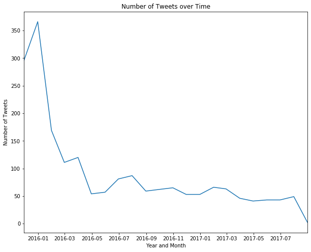

```python
# set figure size and limit x axis
plt.figure(figsize = (10,8))
plt.xlim(datemin, datemax)

# set axis labels and title
plt.xlabel('Year and Month')
plt.ylabel('Number of Tweets')
plt.title('Number of Tweets over Time')

# plot number of tweets vs timestamp
plt.plot(monthly_tweet_count.timestamp, monthly_tweet_count.tweet_id);
```

Looking at the plot, we can see the number of Tweets have been decreasing over time.

1. Which dog name is the most popular?

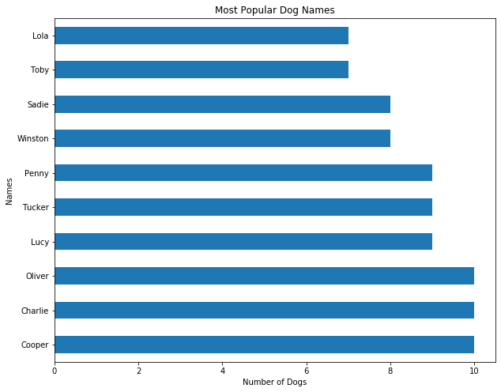

```python
# set figure size
plt.figure(figsize = (10, 8))

# i'm not starting from 0 because the name would be None
# plot number of dogs with a certain name in horizontal bar chart
master_df.name.value_counts()[1:11].plot(kind = 'barh')

# set axis labels and title
plt.xlabel('Number of Dogs')
plt.ylabel('Names')
plt.title('Most Popular Dog Names');
```

From this plot, we can see that the names Cooper, Charlie, and Oliver are the most popular.

```python
# getting all the rows where there are actual dog stage values
dog_stage_rating = master_df.loc[(master_df.dog_stage == 'floofer') | (master_df.dog_stage == 'pupper') |
              (master_df.dog_stage == 'puppo') |(master_df.dog_stage == 'doggo')]
```

```python
# storing them in a different dataframe just to make it easier on myself
dog_stage_rating = dog_stage_rating[['rating_numerator', 'rating_denominator', 'dog_stage']]

# making a rating column, since some numerators and denominators aren't the typical x/10
dog_stage_rating['rating'] = dog_stage_rating.rating_numerator.astype(float) / dog_stage_rating.rating_denominator.astype(float)
```

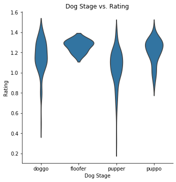

```python
# set the color of the data that will be plotted
base_color = sns.color_palette()[0]

# this is the plot
ax = sns.catplot(x = 'dog_stage', y = 'rating', data = dog_stage_rating,
            kind = 'violin', inner = None, color = base_color)

# set axis labels and title
ax.set(xlabel = 'Dog Stage', ylabel = 'Rating', title = 'Dog Stage vs. Rating')

# show the plot
plt.show()
```

### Sources

- https://developer.twitter.com/en/docs/tweets/data-dictionary/overview/tweet-object
- http://docs.tweepy.org/en/latest/auth_tutorial.html
- https://knowledge.udacity.com/questions/134858
- http://docs.tweepy.org/en/latest/extended_tweets.html
- https://stackoverflow.com/questions/7370801/measure-time-elapsed-in-python
- https://stackoverflow.com/questions/775049/how-do-i-convert-seconds-to-hours-minutes-and-seconds
- https://stackoverflow.com/questions/12309269/how-do-i-write-json-data-to-a-file
- https://pandas.pydata.org/pandas-docs/stable/reference/api/pandas.read_json.html
- https://stackoverflow.com/questions/52580111/how-do-i-set-the-column-width-when-using-pandas-dataframe-to-html
- https://stackoverflow.com/questions/44327999/python-pandas-merge-multiple-dataframes
- https://pandas.pydata.org/pandas-docs/stable/reference/api/pandas.Grouper.html
- https://stackoverflow.com/questions/15315452/selecting-with-complex-criteria-from-pandas-dataframe